# Reproducible Research

David Infortunio

March 26, 2016

The following questions are explored: What is mean total number of steps taken per day? What is the average daily activity pattern?

The following packages are used:

```r
library("ggplot2", lib.loc="~/R/x86_64-pc-linux-gnu-library/3.2")
library("date", lib.loc="~/R/x86_64-pc-linux-gnu-library/3.2")
library("ggplot2", lib.loc="~/R/x86_64-pc-linux-gnu-library/3.2")
library("plyr", lib.loc="~/R/x86_64-pc-linux-gnu-library/3.2")
 options(max.print=1000)
 unzip("activity.zip")
 echo = TRUE  # Always make code visible
options(scipen = 1)  # Turn off scientific notations for numbers
```

The following code opens the file on my computer and sets the working directory:

```r
setwd("/home/david/Documents/dataScience/coursera/reproducible research/project1")
      ACtivit<- read.csv("activity.csv")
```

The following code is designed to anser the following question: What is mean total number of steps taken per day?

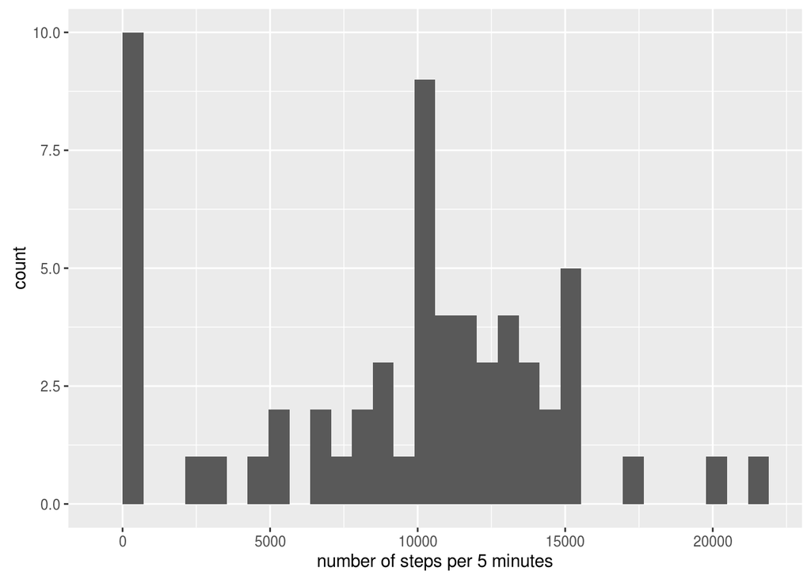

```r
sumstep<-aggregate(ACtivit[,1],by = list(ACtivit[,2]), FUN=sum, na.rm=TRUE)
      stepgraph<-qplot(sumstep[,2], xlab="number of steps per 5 minutes")
      plot(stepgraph+geom_histogram())
```

```r
meastep<-mean(sumstep[,2])

medstep<-median(sumstep[,2])
paste("Median steps per day ", medstep, ". Mean steps per day ", meastep, sep="")
```

```
## [1] "Median steps per day 10395. Mean steps per day 9354.22950819672"
```

The following code is designed to answer the following question: What is the average daily activity pattern and what time in the day has the greatest average number of steps (mean and median)? First the mean steps in each time intervial:

```r
tsteps<-sumstep<-aggregate(ACtivit[,1],by = list(ACtivit[,3]), FUN=mean, na.rm=TRUE)
      png("meanStepsPerDay.png")
plot(tsteps[,1],tsteps[,2],type="l",xlab="time since midnight", ylab="Mean steps")
mtsteps<-tsteps[tsteps[,2]==max(tsteps[,2]),]
paste("The 5 minute intervial with the greatest mean number of steps is ", mtsteps[,1])
```

```
## [1] "The 5 minute intervial with the greatest mean number of steps is  835"
```

```r
   dev.off()
```

Now the median steps in each time intervial:

```r
tsteps2<-sumstep2<-aggregate(ACtivit[,1],by = list(ACtivit[,3]), FUN=median, na.rm=TRUE)
      png("MedianStepsPerDay.png")
plot(tsteps2[,1],tsteps2[,2],type="l",xlab="time since midnight", ylab="Median steps")

mdsteps<-tsteps2[tsteps2[,2]==max(tsteps2[,2]),]
paste("The 5 minute intervial with the greatest median number of steps is ", mdsteps[,1])
```

```
## [1] "The 5 minute intervial with the greatest median number of steps is  845"
```

```r
   dev.off()
```

The following code is designed to answer the following questions: How many missing values are there in the dataset, and what happens if those missing values are replaced with the mean for that 5 minute intervial?

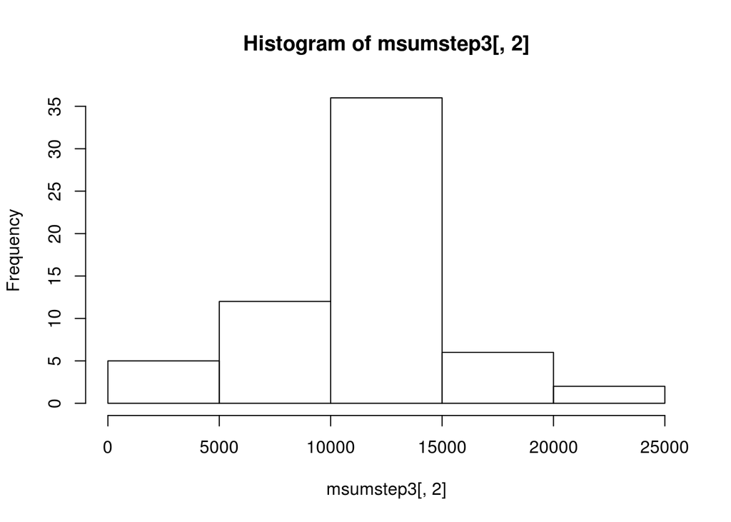

```r
#msstep<-sum(is.na(ACtivit[,1]))
#paste("There are ", msstep, "'NA' values in the data")

ACT2<-ACtivit
for (i in 1:length(ACT2[,1])) {
        if (is.na(ACT2[i,1]) )        {       ACT2[i,1]<-tsteps[tsteps[,1]==ACT2[i,3],2]  }
        }




msumstep3<-aggregate(ACT2[,1],by = list(ACT2[,2]), FUN=sum)

 hist(msumstep3[,2])
```

```r
meastep2<-mean(msumstep3[,2])
 medstep3<-median(msumstep3[,2])
      par(mfcol=c(1,1))
      png("StepsPerDayMissingremoved.png")
  hist(msumstep3[,2], main= paste("Median steps per day ", round(medstep3,2), ". Mean steps per day ", round(meastep2,2), sep=""), xlab = "Steps per day"    )


   dev.off()
```

[figure not shown]

[output not shown]

“Median steps per day 10766.1886792453. Mean steps per day 10766.1886792453”

The following code is designed to answer the following questions: how does behavior differ by day of the week:

```r
wday<-ACT2
wday[,2]<-weekdays(as.Date(wday[,2],"%Y-%m-%d"))
wday[,2]<-gsub("Monday|Tuesday|Wednesday|Thursday|Friday",1,wday[,2],perl=TRUE)
wday[,2]<-gsub("Saturday|Sunday",0,wday[,2],perl=TRUE)
meanNwday<-aggregate(wday[,1],by = list(wday[,2]), FUN=mean)

meanNwday
```

```
##   Group.1        x
## 1       0 42.36640
## 2       1 35.61058
```

```r
paste("Mean steps per 5 minute intervial on weekday ",meanNwday[2,2],". Mean steps per 5 minute intervial on weekend ",meanNwday[1,2],".",sep="")
```

```
## [1] "Mean steps per 5 minute intervial on weekday 35.6105811786629. Mean steps per 5 minute intervial on weekend 42.366401336478."
```

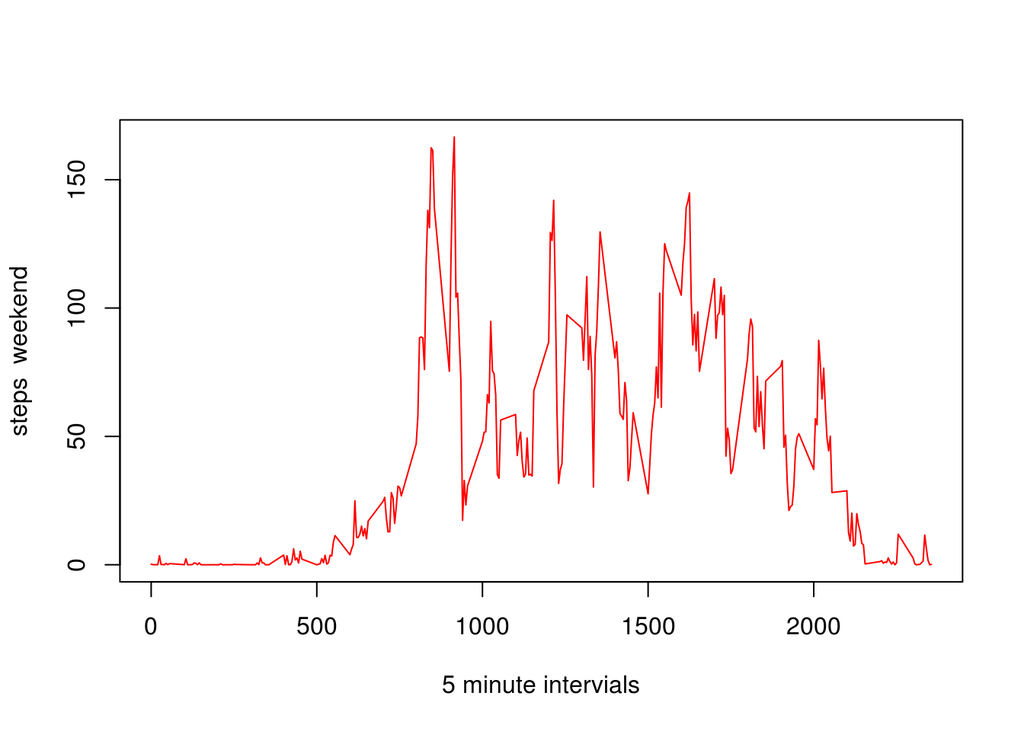

```r
meanwday2<-aggregate(wday[,1],by = list(wday[,2],wday[,3]), FUN=mean)
meanwday2<-rename(meanwday2,replace=c("Group.1"="week"))
meanwday2<-rename(meanwday2,replace=c("Group.2"="TimeIntervial"))


meanwday2[,1]<-gsub("end",1,meanwday2[,1],perl=TRUE)
meanwday2[,1]<-gsub("Weekday",0,meanwday2[,1],perl=TRUE)


dayt<-split(meanwday2, f=meanwday2$week)
wend<-dayt[[1]]
wdays<-dayt[[2]]
plot(wend$TimeIntervial,wend$x, col="red",type="l", ylab="steps  weekend",xlab  ="5 minute intervials")
```

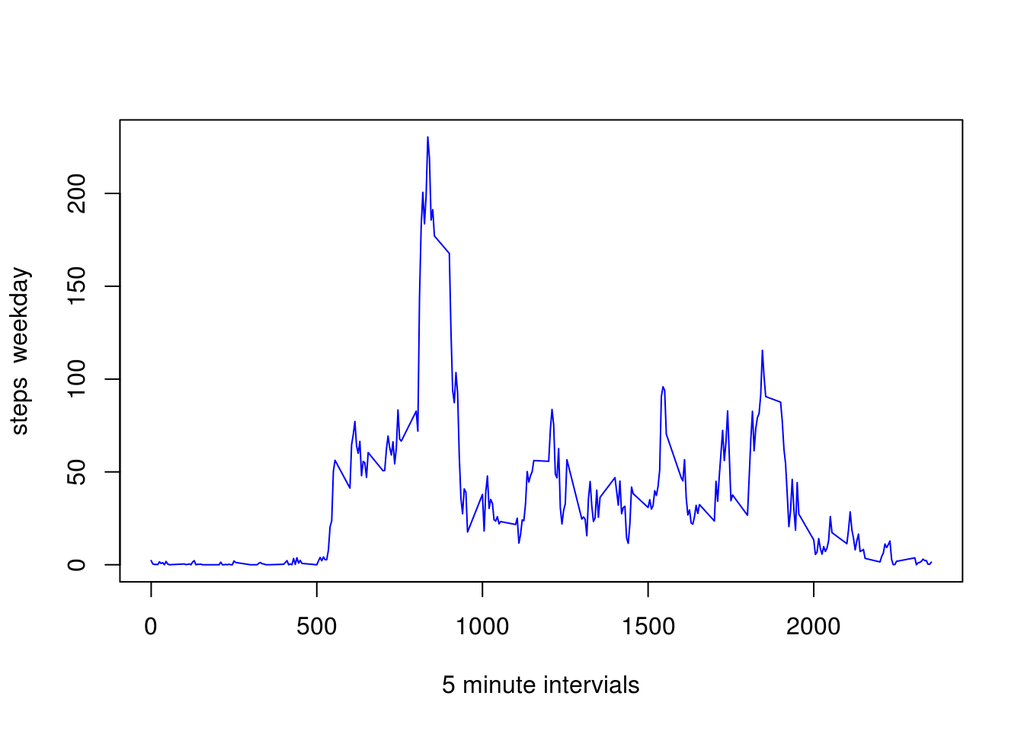

```r
plot(wdays$TimeIntervial,wdays$x, col="blue",type="l", xlab = "5 minute intervials",ylab="steps  weekday")
```

```r
png("WeekdayVsWeekend.png")
par(mfcol=c(2,1))



plot(wend$TimeIntervial,wend$x, col="red",type="l", ylab="steps  weekend",xlab  ="5 minute intervials")

plot(wdays$TimeIntervial,wdays$x, col="blue",type="l", xlab = "5 minute intervials",ylab="steps  weekday")
dev.off()
```

So ithe mean steps per 5 minute intervial on the weekend is higher